## Create data frame with these two column vectors

## x = 1:30

## y = x^3

A data frame is a table or a two-dimensional array-like structure in which each column contains values of one variable and each row contains one set of values from each column.

```r
x <- 1:30
y <- x^3
df <- data.frame(x,y)
print(head(df))
```

```
##   x   y
## 1 1   1
## 2 2   8
## 3 3  27
## 4 4  64
## 5 5 125
## 6 6 216
```

## Create plot of x and y variables and interpret it carefully.

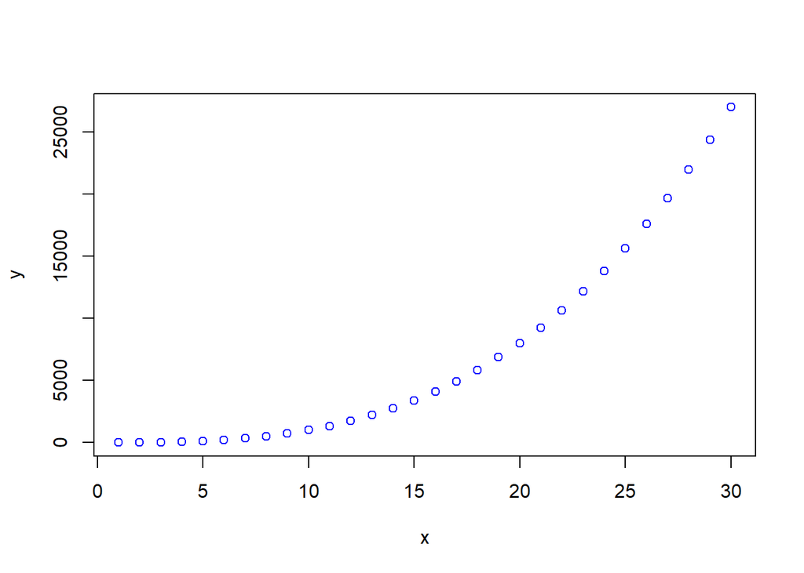

```r
plot(df$x, df$y, xlab="x", ylab="y", col="blue")
```

## Get appropriate correlation coefficient of this data in and interpret it carefully.

Since the relation is nonlinear so use spearman correlation coefficient. Spearman correlation evaluates the monotonic relationship.

```r
corr <- cor.test(x=df$x, y=df$y, method='spearman')
print(corr)
```

```
##
##  Spearman's rank correlation rho
##
## data:  df$x and df$y
## S = 0, p-value < 2.2e-16
## alternative hypothesis: true rho is not equal to 0
## sample estimates:
## rho
##   1
```

A Spearman correlation 1 results when the two variables being compared are monotonically related, even if the relationship is not linear. This means that all data points with greater x values than that of a given data point will have greater y values as well.

## Transform the plot to linear using appropriate mathematical function.

Transforming non linear relation to linear relation using log().

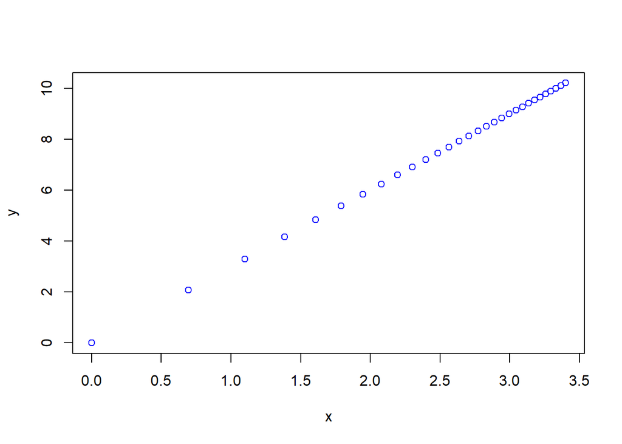

```r
plot(log(df$x), log(df$y), xlab = 'x', ylab = 'y', col="blue")
```

## Get appropriate correlation coefficient now in R Studio and interpret it carefully too.

```r
pear_method = cor(log(df$x), log(df$y), method='pearson')
print(pear_method)
```

```
## [1] 1
```

Pearson’s Correlation Coefficient is a linear correlation coefficient that returns a value of between -1 and +1. +1 means that there is a strong positive correlation.

## Create a new column vector z defined in the slide 18 of session two slide deck.

```r
z <- c(1,2,2,2,3,3,3,3,3,3,3,4,4,4,4,5,5,6)
print(z)
```

```
##  [1] 1 2 2 2 3 3 3 3 3 3 3 4 4 4 4 5 5 6
```

## Create a histogram of z variable and interpret it carefully.

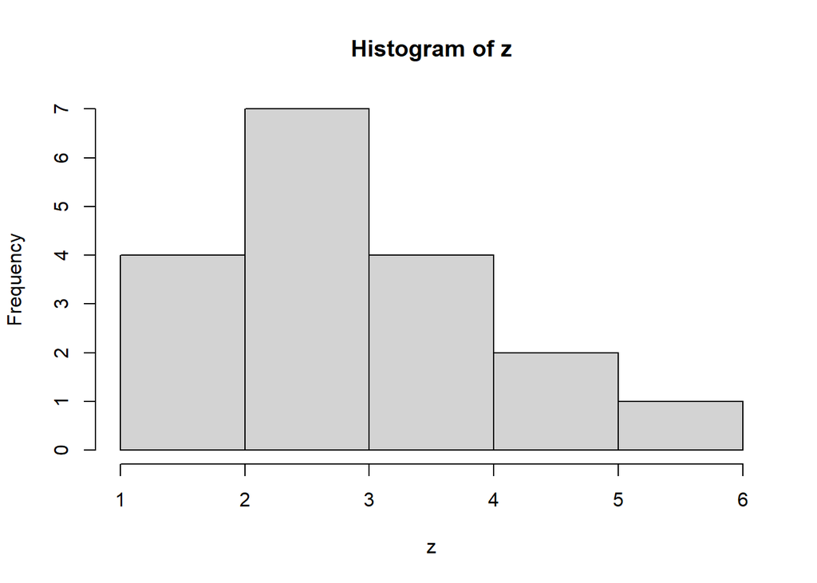

```r
hist(z)
```

Z is positive or right skewed. Here the distribution in which most values are clustered around the left tail of the distribution while the right tail of the distribution is longer.

## Get summary statistics of z variable and interpret it carefully.

```r
summary(z)
```

```
##    Min. 1st Qu.  Median    Mean 3rd Qu.    Max.
##   1.000   3.000   3.000   3.333   4.000   6.000
```

Summary() gives the better idea of distribution of the variable. The summary of data gives Q1, Q2, Q3, Q4 (quartiles) and min max of the data. Interquartile range (IQR) of data = Q3-Q1 = 1 i.e the middle 50% of data betweem 3 and 4 is 1. The minimum and maximum of data will be 1 and 6 i.e the data lies between 1 and 6.

## Get box-plot of z variable and interpret the result carefully.

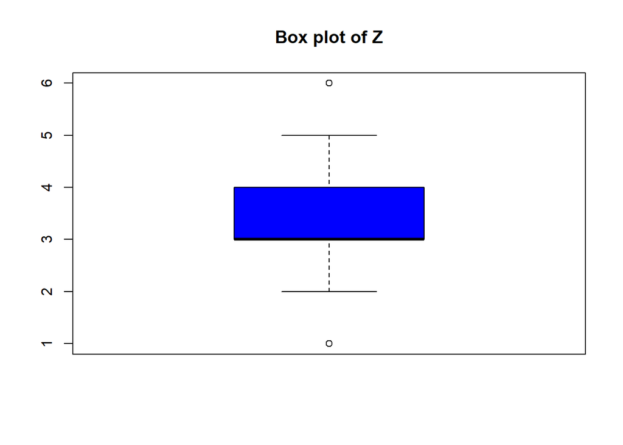

```r
boxplot(z, col = "blue", main="Box plot of Z")
```

A boxplot is a standardized way of displaying the distribution of data based on a five number summary (“minimum”, first quartile (Q1), median, third quartile (Q3), and “maximum”). It tells about outliers and what their values are. We can also find inter quartile range (IQR) = Q3-Q1.